# Risk Factor Analysis

## Outcome Variable

**Outcome Variable:** wast_rec90d

## Predictor Variables

**Intervention Variable:** meducyrs

**Adjustment Set:**

- arm
- W_mage
- feducyrs
- hhwealth_quart
- W_mhtcm
- W_gagebrth
- W_birthwt
- W_birthlen
- W_nrooms
- impfloor
- impsan
- safeh20
- delta_W_mage
- delta_feducyrs
- delta_hhwealth_quart
- delta_W_mhtcm
- delta_W_gagebrth
- delta_W_birthwt
- delta_W_birthlen
- delta_W_nrooms
- delta_impfloor
- delta_impsan
- delta_safeh20

## Stratifying Variables

The analysis was stratified on these variable(s):

- agecat
- studyid
- country

## Data Summary

| agecat | studyid | country | meducyrs | wast_rec90d | n_cell | n |
| --- | --- | --- | --- | --- | --- | --- |
| 0-24 months | ki0047075b-MAL-ED | BANGLADESH | Low | 0 | 10 | 86 |
| 0-24 months | ki0047075b-MAL-ED | BANGLADESH | Low | 1 | 22 | 86 |
| 0-24 months | ki0047075b-MAL-ED | BANGLADESH | Medium | 0 | 6 | 86 |
| 0-24 months | ki0047075b-MAL-ED | BANGLADESH | Medium | 1 | 21 | 86 |
| 0-24 months | ki0047075b-MAL-ED | BANGLADESH | High | 0 | 7 | 86 |
| 0-24 months | ki0047075b-MAL-ED | BANGLADESH | High | 1 | 20 | 86 |
| 0-24 months | ki0047075b-MAL-ED | BRAZIL | Low | 0 | 4 | 23 |
| 0-24 months | ki0047075b-MAL-ED | BRAZIL | Low | 1 | 6 | 23 |
| 0-24 months | ki0047075b-MAL-ED | BRAZIL | Medium | 0 | 2 | 23 |
| 0-24 months | ki0047075b-MAL-ED | BRAZIL | Medium | 1 | 8 | 23 |
| 0-24 months | ki0047075b-MAL-ED | BRAZIL | High | 0 | 0 | 23 |
| 0-24 months | ki0047075b-MAL-ED | BRAZIL | High | 1 | 3 | 23 |
| 0-24 months | ki0047075b-MAL-ED | INDIA | Low | 0 | 21 | 153 |
| 0-24 months | ki0047075b-MAL-ED | INDIA | Low | 1 | 42 | 153 |
| 0-24 months | ki0047075b-MAL-ED | INDIA | Medium | 0 | 25 | 153 |
| 0-24 months | ki0047075b-MAL-ED | INDIA | Medium | 1 | 34 | 153 |
| 0-24 months | ki0047075b-MAL-ED | INDIA | High | 0 | 12 | 153 |
| 0-24 months | ki0047075b-MAL-ED | INDIA | High | 1 | 19 | 153 |
| 0-24 months | ki0047075b-MAL-ED | NEPAL | Low | 0 | 5 | 88 |
| 0-24 months | ki0047075b-MAL-ED | NEPAL | Low | 1 | 28 | 88 |
| 0-24 months | ki0047075b-MAL-ED | NEPAL | Medium | 0 | 10 | 88 |
| 0-24 months | ki0047075b-MAL-ED | NEPAL | Medium | 1 | 29 | 88 |
| 0-24 months | ki0047075b-MAL-ED | NEPAL | High | 0 | 2 | 88 |
| 0-24 months | ki0047075b-MAL-ED | NEPAL | High | 1 | 14 | 88 |
| 0-24 months | ki0047075b-MAL-ED | PERU | Low | 0 | 2 | 34 |
| 0-24 months | ki0047075b-MAL-ED | PERU | Low | 1 | 14 | 34 |
| 0-24 months | ki0047075b-MAL-ED | PERU | Medium | 0 | 4 | 34 |
| 0-24 months | ki0047075b-MAL-ED | PERU | Medium | 1 | 11 | 34 |
| 0-24 months | ki0047075b-MAL-ED | PERU | High | 0 | 0 | 34 |
| 0-24 months | ki0047075b-MAL-ED | PERU | High | 1 | 3 | 34 |

[output cut: 438 more lines]

The following strata were considered:

- agecat: 0-24 months, studyid: ki0047075b-MAL-ED, country: BANGLADESH
- agecat: 0-24 months, studyid: ki0047075b-MAL-ED, country: BRAZIL
- agecat: 0-24 months, studyid: ki0047075b-MAL-ED, country: INDIA
- agecat: 0-24 months, studyid: ki0047075b-MAL-ED, country: NEPAL
- agecat: 0-24 months, studyid: ki0047075b-MAL-ED, country: PERU
- agecat: 0-24 months, studyid: ki0047075b-MAL-ED, country: SOUTH AFRICA
- agecat: 0-24 months, studyid: ki0047075b-MAL-ED, country: TANZANIA, UNITED REPUBLIC OF
- agecat: 0-24 months, studyid: ki1000108-CMC-V-BCS-2002, country: INDIA
- agecat: 0-24 months, studyid: ki1000108-IRC, country: INDIA
- agecat: 0-24 months, studyid: ki1000109-EE, country: PAKISTAN
- agecat: 0-24 months, studyid: ki1000304b-SAS-CompFeed, country: INDIA
- agecat: 0-24 months, studyid: ki1000304b-SAS-FoodSuppl, country: INDIA
- agecat: 0-24 months, studyid: ki1017093-NIH-Birth, country: BANGLADESH
- agecat: 0-24 months, studyid: ki1017093b-PROVIDE, country: BANGLADESH
- agecat: 0-24 months, studyid: ki1017093c-NIH-Crypto, country: BANGLADESH
- agecat: 0-24 months, studyid: ki1066203-TanzaniaChild2, country: TANZANIA, UNITED REPUBLIC OF
- agecat: 0-24 months, studyid: ki1112895-Guatemala BSC, country: GUATEMALA
- agecat: 0-24 months, studyid: ki1113344-GMS-Nepal, country: NEPAL
- agecat: 0-24 months, studyid: ki1119695-PROBIT, country: BELARUS
- agecat: 0-24 months, studyid: ki1126311-ZVITAMBO, country: ZIMBABWE
- agecat: 0-24 months, studyid: ki1135781-COHORTS, country: GUATEMALA
- agecat: 0-24 months, studyid: ki1135781-COHORTS, country: INDIA
- agecat: 0-24 months, studyid: ki1135781-COHORTS, country: PHILIPPINES
- agecat: 0-24 months, studyid: ki1148112-LCNI-5, country: MALAWI
- agecat: 0-24 months, studyid: kiGH5241-JiVitA-3, country: BANGLADESH
- agecat: 0-24 months, studyid: kiGH5241-JiVitA-4, country: BANGLADESH
- agecat: 0-6 months, studyid: ki0047075b-MAL-ED, country: BANGLADESH
- agecat: 0-6 months, studyid: ki0047075b-MAL-ED, country: BRAZIL
- agecat: 0-6 months, studyid: ki0047075b-MAL-ED, country: INDIA
- agecat: 0-6 months, studyid: ki0047075b-MAL-ED, country: NEPAL
- agecat: 0-6 months, studyid: ki0047075b-MAL-ED, country: PERU
- agecat: 0-6 months, studyid: ki0047075b-MAL-ED, country: SOUTH AFRICA
- agecat: 0-6 months, studyid: ki0047075b-MAL-ED, country: TANZANIA, UNITED REPUBLIC OF
- agecat: 0-6 months, studyid: ki1000108-CMC-V-BCS-2002, country: INDIA
- agecat: 0-6 months, studyid: ki1000108-IRC, country: INDIA
- agecat: 0-6 months, studyid: ki1000109-EE, country: PAKISTAN
- agecat: 0-6 months, studyid: ki1000304b-SAS-CompFeed, country: INDIA
- agecat: 0-6 months, studyid: ki1000304b-SAS-FoodSuppl, country: INDIA
- agecat: 0-6 months, studyid: ki1017093-NIH-Birth, country: BANGLADESH
- agecat: 0-6 months, studyid: ki1017093b-PROVIDE, country: BANGLADESH
- agecat: 0-6 months, studyid: ki1017093c-NIH-Crypto, country: BANGLADESH
- agecat: 0-6 months, studyid: ki1066203-TanzaniaChild2, country: TANZANIA, UNITED REPUBLIC OF
- agecat: 0-6 months, studyid: ki1112895-Guatemala BSC, country: GUATEMALA
- agecat: 0-6 months, studyid: ki1113344-GMS-Nepal, country: NEPAL
- agecat: 0-6 months, studyid: ki1119695-PROBIT, country: BELARUS
- agecat: 0-6 months, studyid: ki1126311-ZVITAMBO, country: ZIMBABWE
- agecat: 0-6 months, studyid: ki1135781-COHORTS, country: GUATEMALA
- agecat: 0-6 months, studyid: ki1135781-COHORTS, country: INDIA
- agecat: 0-6 months, studyid: ki1135781-COHORTS, country: PHILIPPINES
- agecat: 0-6 months, studyid: ki1148112-LCNI-5, country: MALAWI
- agecat: 0-6 months, studyid: kiGH5241-JiVitA-3, country: BANGLADESH
- agecat: 0-6 months, studyid: kiGH5241-JiVitA-4, country: BANGLADESH
- agecat: 6-24 months, studyid: ki0047075b-MAL-ED, country: BANGLADESH
- agecat: 6-24 months, studyid: ki0047075b-MAL-ED, country: BRAZIL
- agecat: 6-24 months, studyid: ki0047075b-MAL-ED, country: INDIA
- agecat: 6-24 months, studyid: ki0047075b-MAL-ED, country: NEPAL
- agecat: 6-24 months, studyid: ki0047075b-MAL-ED, country: PERU
- agecat: 6-24 months, studyid: ki0047075b-MAL-ED, country: SOUTH AFRICA
- agecat: 6-24 months, studyid: ki0047075b-MAL-ED, country: TANZANIA, UNITED REPUBLIC OF
- agecat: 6-24 months, studyid: ki1000108-CMC-V-BCS-2002, country: INDIA
- agecat: 6-24 months, studyid: ki1000108-IRC, country: INDIA
- agecat: 6-24 months, studyid: ki1000109-EE, country: PAKISTAN
- agecat: 6-24 months, studyid: ki1000304b-SAS-CompFeed, country: INDIA
- agecat: 6-24 months, studyid: ki1000304b-SAS-FoodSuppl, country: INDIA
- agecat: 6-24 months, studyid: ki1017093-NIH-Birth, country: BANGLADESH
- agecat: 6-24 months, studyid: ki1017093b-PROVIDE, country: BANGLADESH
- agecat: 6-24 months, studyid: ki1017093c-NIH-Crypto, country: BANGLADESH
- agecat: 6-24 months, studyid: ki1066203-TanzaniaChild2, country: TANZANIA, UNITED REPUBLIC OF
- agecat: 6-24 months, studyid: ki1112895-Guatemala BSC, country: GUATEMALA
- agecat: 6-24 months, studyid: ki1113344-GMS-Nepal, country: NEPAL
- agecat: 6-24 months, studyid: ki1119695-PROBIT, country: BELARUS
- agecat: 6-24 months, studyid: ki1126311-ZVITAMBO, country: ZIMBABWE
- agecat: 6-24 months, studyid: ki1135781-COHORTS, country: GUATEMALA
- agecat: 6-24 months, studyid: ki1135781-COHORTS, country: INDIA
- agecat: 6-24 months, studyid: ki1135781-COHORTS, country: PHILIPPINES
- agecat: 6-24 months, studyid: ki1148112-LCNI-5, country: MALAWI
- agecat: 6-24 months, studyid: kiGH5241-JiVitA-3, country: BANGLADESH
- agecat: 6-24 months, studyid: kiGH5241-JiVitA-4, country: BANGLADESH

### Dropped Strata

Some strata were dropped due to rare outcomes:

- agecat: 0-24 months, studyid: ki0047075b-MAL-ED, country: BRAZIL
- agecat: 0-24 months, studyid: ki0047075b-MAL-ED, country: NEPAL
- agecat: 0-24 months, studyid: ki0047075b-MAL-ED, country: PERU
- agecat: 0-24 months, studyid: ki0047075b-MAL-ED, country: SOUTH AFRICA
- agecat: 0-24 months, studyid: ki0047075b-MAL-ED, country: TANZANIA, UNITED REPUBLIC OF
- agecat: 0-24 months, studyid: ki1000109-EE, country: PAKISTAN
- agecat: 0-24 months, studyid: ki1000304b-SAS-FoodSuppl, country: INDIA
- agecat: 0-24 months, studyid: ki1112895-Guatemala BSC, country: GUATEMALA
- agecat: 0-24 months, studyid: ki1148112-LCNI-5, country: MALAWI
- agecat: 0-6 months, studyid: ki0047075b-MAL-ED, country: BANGLADESH
- agecat: 0-6 months, studyid: ki0047075b-MAL-ED, country: BRAZIL
- agecat: 0-6 months, studyid: ki0047075b-MAL-ED, country: NEPAL
- agecat: 0-6 months, studyid: ki0047075b-MAL-ED, country: PERU
- agecat: 0-6 months, studyid: ki0047075b-MAL-ED, country: SOUTH AFRICA
- agecat: 0-6 months, studyid: ki0047075b-MAL-ED, country: TANZANIA, UNITED REPUBLIC OF
- agecat: 0-6 months, studyid: ki1000109-EE, country: PAKISTAN
- agecat: 0-6 months, studyid: ki1000304b-SAS-FoodSuppl, country: INDIA
- agecat: 0-6 months, studyid: ki1066203-TanzaniaChild2, country: TANZANIA, UNITED REPUBLIC OF
- agecat: 0-6 months, studyid: ki1112895-Guatemala BSC, country: GUATEMALA
- agecat: 0-6 months, studyid: ki1148112-LCNI-5, country: MALAWI
- agecat: 6-24 months, studyid: ki0047075b-MAL-ED, country: BANGLADESH
- agecat: 6-24 months, studyid: ki0047075b-MAL-ED, country: BRAZIL
- agecat: 6-24 months, studyid: ki0047075b-MAL-ED, country: NEPAL
- agecat: 6-24 months, studyid: ki0047075b-MAL-ED, country: PERU
- agecat: 6-24 months, studyid: ki0047075b-MAL-ED, country: SOUTH AFRICA
- agecat: 6-24 months, studyid: ki0047075b-MAL-ED, country: TANZANIA, UNITED REPUBLIC OF
- agecat: 6-24 months, studyid: ki1000109-EE, country: PAKISTAN
- agecat: 6-24 months, studyid: ki1000304b-SAS-FoodSuppl, country: INDIA
- agecat: 6-24 months, studyid: ki1017093c-NIH-Crypto, country: BANGLADESH
- agecat: 6-24 months, studyid: ki1112895-Guatemala BSC, country: GUATEMALA
- agecat: 6-24 months, studyid: ki1135781-COHORTS, country: GUATEMALA
- agecat: 6-24 months, studyid: ki1135781-COHORTS, country: INDIA
- agecat: 6-24 months, studyid: ki1148112-LCNI-5, country: MALAWI
- agecat: 6-24 months, studyid: kiGH5241-JiVitA-3, country: BANGLADESH
- agecat: 6-24 months, studyid: kiGH5241-JiVitA-4, country: BANGLADESH

## Methods Detail

We’re interested in the causal parameters $E[Y_a]$ for all values of $a \in \mathcal{A}$. These parameters represent the mean outcome if, possibly contrary to fact, we intervened to set all units to have $A=a$. Under the randomization and positivity assumptions, these are identified by the statistical parameters $\psi_a=E_W[E_{Y|A,W}(Y|A=a,W)]$. In addition, we’re interested in the mean of $Y$, $E[Y]$ under no intervention (the observed mean). We will estimate these parameters by using SuperLearner to fit the relevant likelihood factors – $E_{Y|A,W}(Y|A=a,W)$ and $p(A=a|W)$, and then updating our likelihood fit using a joint TMLE.

For unadjusted analyses ($W=\{\}$), initial likelihoods were estimated using Lrnr_glm to estimate the simple $E(Y|A)$ and Lrnr_mean to estimate $p(A)$. For adjusted analyses, a small library containing Lrnr_glmnet, Lrnr_xgboost, and Lrnr_mean was used.

Having estimated these parameters, we will then use the delta method to estimate relative risks and attributable risks relative to a prespecified baseline level of $A$.

# Results Detail

## Results Plots

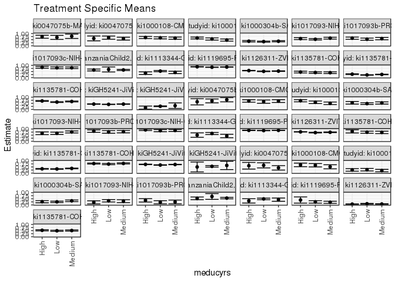

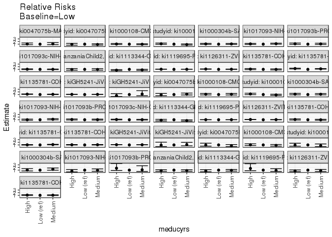

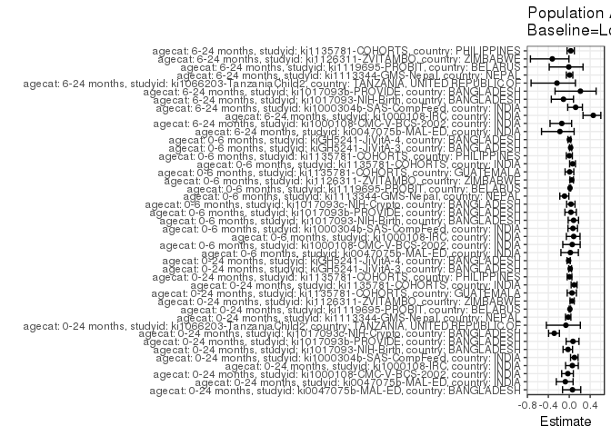

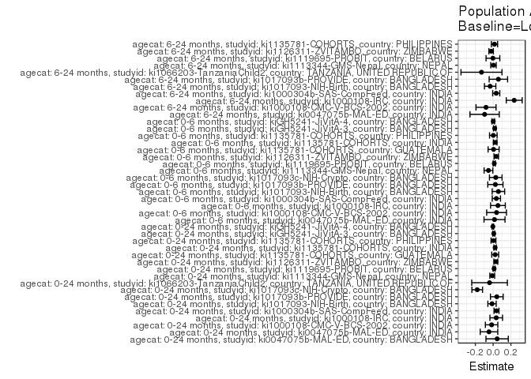

## Results Table

### Parameter: TSM

| agecat | studyid | country | intervention_level | baseline_level | estimate | ci_lower | ci_upper |
| --- | --- | --- | --- | --- | --- | --- | --- |
| 0-24 months | ki0047075b-MAL-ED | BANGLADESH | Low | NA | 0.6875000 | 0.5204085 | 0.8545915 |
| 0-24 months | ki0047075b-MAL-ED | BANGLADESH | Medium | NA | 0.7777778 | 0.5988250 | 0.9567305 |
| 0-24 months | ki0047075b-MAL-ED | BANGLADESH | High | NA | 0.7407407 | 0.6174221 | 0.8640594 |
| 0-24 months | ki0047075b-MAL-ED | INDIA | Low | NA | 0.6677095 | 0.5394515 | 0.7959676 |
| 0-24 months | ki0047075b-MAL-ED | INDIA | Medium | NA | 0.5823298 | 0.4627004 | 0.7019593 |
| 0-24 months | ki0047075b-MAL-ED | INDIA | High | NA | 0.6017138 | 0.4045797 | 0.7988478 |
| 0-24 months | ki1000108-CMC-V-BCS-2002 | INDIA | Low | NA | 0.6492611 | 0.5644306 | 0.7340916 |
| 0-24 months | ki1000108-CMC-V-BCS-2002 | INDIA | Medium | NA | 0.6251682 | 0.5362748 | 0.7140617 |
| 0-24 months | ki1000108-CMC-V-BCS-2002 | INDIA | High | NA | 0.6802325 | 0.5944980 | 0.7659670 |
| 0-24 months | ki1000108-IRC | INDIA | Low | NA | 0.5550067 | 0.4637862 | 0.6462271 |
| 0-24 months | ki1000108-IRC | INDIA | Medium | NA | 0.4685979 | 0.3801704 | 0.5570254 |
| 0-24 months | ki1000108-IRC | INDIA | High | NA | 0.6372188 | 0.5603815 | 0.7140560 |
| 0-24 months | ki1000304b-SAS-CompFeed | INDIA | Low | NA | 0.3428084 | 0.3023502 | 0.3832666 |
| 0-24 months | ki1000304b-SAS-CompFeed | INDIA | Medium | NA | 0.3718841 | 0.3270414 | 0.4167268 |
| 0-24 months | ki1000304b-SAS-CompFeed | INDIA | High | NA | 0.3731289 | 0.3168901 | 0.4293677 |
| 0-24 months | ki1017093-NIH-Birth | BANGLADESH | Low | NA | 0.5328127 | 0.4723522 | 0.5932732 |
| 0-24 months | ki1017093-NIH-Birth | BANGLADESH | Medium | NA | 0.6236444 | 0.5497369 | 0.6975518 |
| 0-24 months | ki1017093-NIH-Birth | BANGLADESH | High | NA | 0.5843851 | 0.5055896 | 0.6631805 |
| 0-24 months | ki1017093b-PROVIDE | BANGLADESH | Low | NA | 0.5416100 | 0.4510611 | 0.6321590 |
| 0-24 months | ki1017093b-PROVIDE | BANGLADESH | Medium | NA | 0.5894396 | 0.4945579 | 0.6843212 |
| 0-24 months | ki1017093b-PROVIDE | BANGLADESH | High | NA | 0.6229817 | 0.5332260 | 0.7127375 |
| 0-24 months | ki1017093c-NIH-Crypto | BANGLADESH | Low | NA | 0.8029590 | 0.7301120 | 0.8758060 |
| 0-24 months | ki1017093c-NIH-Crypto | BANGLADESH | Medium | NA | 0.8045366 | 0.7394809 | 0.8695923 |
| 0-24 months | ki1017093c-NIH-Crypto | BANGLADESH | High | NA | 0.8407086 | 0.7668361 | 0.9145811 |
| 0-24 months | ki1066203-TanzaniaChild2 | TANZANIA, UNITED REPUBLIC OF | Low | NA | 0.6666667 | 0.4628279 | 0.8705055 |
| 0-24 months | ki1066203-TanzaniaChild2 | TANZANIA, UNITED REPUBLIC OF | Medium | NA | 0.6254902 | 0.5809696 | 0.6700108 |
| 0-24 months | ki1066203-TanzaniaChild2 | TANZANIA, UNITED REPUBLIC OF | High | NA | 0.6235955 | 0.5481204 | 0.6990706 |
| 0-24 months | ki1113344-GMS-Nepal | NEPAL | Low | NA | 0.5315264 | 0.4810458 | 0.5820070 |
| 0-24 months | ki1113344-GMS-Nepal | NEPAL | Medium | NA | 0.4239497 | 0.3272284 | 0.5206710 |
| 0-24 months | ki1113344-GMS-Nepal | NEPAL | High | NA | 0.3655456 | 0.2615275 | 0.4695637 |

[output cut: 99 more lines]

### Parameter: E(Y)

| agecat | studyid | country | intervention_level | baseline_level | estimate | ci_lower | ci_upper |
| --- | --- | --- | --- | --- | --- | --- | --- |
| 0-24 months | ki0047075b-MAL-ED | BANGLADESH | NA | NA | 0.7325581 | 0.6399608 | 0.8251555 |
| 0-24 months | ki0047075b-MAL-ED | INDIA | NA | NA | 0.6209150 | 0.5357837 | 0.7060464 |
| 0-24 months | ki1000108-CMC-V-BCS-2002 | INDIA | NA | NA | 0.6319018 | 0.5759256 | 0.6878781 |
| 0-24 months | ki1000108-IRC | INDIA | NA | NA | 0.5898734 | 0.5376978 | 0.6420491 |
| 0-24 months | ki1000304b-SAS-CompFeed | INDIA | NA | NA | 0.3808354 | 0.3457640 | 0.4159068 |
| 0-24 months | ki1017093-NIH-Birth | BANGLADESH | NA | NA | 0.5201900 | 0.4695846 | 0.5707955 |
| 0-24 months | ki1017093b-PROVIDE | BANGLADESH | NA | NA | 0.5830619 | 0.5262762 | 0.6398476 |
| 0-24 months | ki1017093c-NIH-Crypto | BANGLADESH | NA | NA | 0.6237942 | 0.5698223 | 0.6777662 |
| 0-24 months | ki1066203-TanzaniaChild2 | TANZANIA, UNITED REPUBLIC OF | NA | NA | 0.6264045 | 0.5887191 | 0.6640899 |
| 0-24 months | ki1113344-GMS-Nepal | NEPAL | NA | NA | 0.5215054 | 0.4764383 | 0.5665724 |
| 0-24 months | ki1119695-PROBIT | BELARUS | NA | NA | 0.8612051 | 0.8511051 | 0.8713052 |
| 0-24 months | ki1126311-ZVITAMBO | ZIMBABWE | NA | NA | 0.5438498 | 0.5273663 | 0.5603333 |
| 0-24 months | ki1135781-COHORTS | GUATEMALA | NA | NA | 0.4403183 | 0.3884516 | 0.4921850 |
| 0-24 months | ki1135781-COHORTS | INDIA | NA | NA | 0.2397357 | 0.2214428 | 0.2580286 |
| 0-24 months | ki1135781-COHORTS | PHILIPPINES | NA | NA | 0.6068680 | 0.5823645 | 0.6313715 |
| 0-24 months | kiGH5241-JiVitA-3 | BANGLADESH | NA | NA | 0.4227718 | 0.4116444 | 0.4338991 |
| 0-24 months | kiGH5241-JiVitA-4 | BANGLADESH | NA | NA | 0.2581736 | 0.2292825 | 0.2870648 |
| 0-6 months | ki0047075b-MAL-ED | INDIA | NA | NA | 0.7123288 | 0.6046595 | 0.8199981 |
| 0-6 months | ki1000108-CMC-V-BCS-2002 | INDIA | NA | NA | 0.6748768 | 0.6092233 | 0.7405304 |
| 0-6 months | ki1000108-IRC | INDIA | NA | NA | 0.6375000 | 0.5751450 | 0.6998550 |
| 0-6 months | ki1000304b-SAS-CompFeed | INDIA | NA | NA | 0.5131965 | 0.4596632 | 0.5667297 |
| 0-6 months | ki1017093-NIH-Birth | BANGLADESH | NA | NA | 0.7130045 | 0.6535890 | 0.7724200 |
| 0-6 months | ki1017093b-PROVIDE | BANGLADESH | NA | NA | 0.7880435 | 0.7295878 | 0.8464992 |
| 0-6 months | ki1017093c-NIH-Crypto | BANGLADESH | NA | NA | 0.8939394 | 0.8505280 | 0.9373508 |
| 0-6 months | ki1113344-GMS-Nepal | NEPAL | NA | NA | 0.5810056 | 0.5082784 | 0.6537327 |
| 0-6 months | ki1119695-PROBIT | BELARUS | NA | NA | 0.8855266 | 0.8758983 | 0.8951550 |
| 0-6 months | ki1126311-ZVITAMBO | ZIMBABWE | NA | NA | 0.7432325 | 0.7261601 | 0.7603048 |
| 0-6 months | ki1135781-COHORTS | GUATEMALA | NA | NA | 0.7452830 | 0.6866274 | 0.8039386 |
| 0-6 months | ki1135781-COHORTS | INDIA | NA | NA | 0.3595188 | 0.3344897 | 0.3845478 |
| 0-6 months | ki1135781-COHORTS | PHILIPPINES | NA | NA | 0.7367021 | 0.7051294 | 0.7682749 |
| 0-6 months | kiGH5241-JiVitA-3 | BANGLADESH | NA | NA | 0.6754701 | 0.6621313 | 0.6888089 |
| 0-6 months | kiGH5241-JiVitA-4 | BANGLADESH | NA | NA | 0.5514403 | 0.4887790 | 0.6141017 |
| 6-24 months | ki0047075b-MAL-ED | INDIA | NA | NA | 0.5375000 | 0.4127227 | 0.6622773 |
| 6-24 months | ki1000108-CMC-V-BCS-2002 | INDIA | NA | NA | 0.5609756 | 0.4682842 | 0.6536670 |
| 6-24 months | ki1000108-IRC | INDIA | NA | NA | 0.5161290 | 0.4322562 | 0.6000019 |
| 6-24 months | ki1000304b-SAS-CompFeed | INDIA | NA | NA | 0.2854123 | 0.2436284 | 0.3271961 |
| 6-24 months | ki1017093-NIH-Birth | BANGLADESH | NA | NA | 0.3030303 | 0.2377927 | 0.3682679 |
| 6-24 months | ki1017093b-PROVIDE | BANGLADESH | NA | NA | 0.2764228 | 0.1950773 | 0.3577682 |
| 6-24 months | ki1066203-TanzaniaChild2 | TANZANIA, UNITED REPUBLIC OF | NA | NA | 0.5564516 | 0.5041613 | 0.6087419 |
| 6-24 months | ki1113344-GMS-Nepal | NEPAL | NA | NA | 0.4934037 | 0.4386266 | 0.5481808 |
| 6-24 months | ki1119695-PROBIT | BELARUS | NA | NA | 0.2440476 | 0.1791134 | 0.3089818 |
| 6-24 months | ki1126311-ZVITAMBO | ZIMBABWE | NA | NA | 0.0700095 | 0.0547600 | 0.0852589 |
| 6-24 months | ki1135781-COHORTS | PHILIPPINES | NA | NA | 0.5026681 | 0.4688378 | 0.5364984 |

### Parameter: RR

| agecat | studyid | country | intervention_level | baseline_level | estimate | ci_lower | ci_upper |
| --- | --- | --- | --- | --- | --- | --- | --- |
| 0-24 months | ki0047075b-MAL-ED | BANGLADESH | Low | Low | 1.0000000 | 1.0000000 | 1.0000000 |
| 0-24 months | ki0047075b-MAL-ED | BANGLADESH | Medium | Low | 1.1313131 | 0.8095986 | 1.5808692 |
| 0-24 months | ki0047075b-MAL-ED | BANGLADESH | High | Low | 1.0774411 | 0.8022294 | 1.4470665 |
| 0-24 months | ki0047075b-MAL-ED | INDIA | Low | Low | 1.0000000 | 1.0000000 | 1.0000000 |
| 0-24 months | ki0047075b-MAL-ED | INDIA | Medium | Low | 0.8721304 | 0.6586117 | 1.1548709 |
| 0-24 months | ki0047075b-MAL-ED | INDIA | High | Low | 0.9011610 | 0.6177731 | 1.3145459 |
| 0-24 months | ki1000108-CMC-V-BCS-2002 | INDIA | Low | Low | 1.0000000 | 1.0000000 | 1.0000000 |
| 0-24 months | ki1000108-CMC-V-BCS-2002 | INDIA | Medium | Low | 0.9628919 | 0.8001899 | 1.1586759 |
| 0-24 months | ki1000108-CMC-V-BCS-2002 | INDIA | High | Low | 1.0477025 | 0.8779714 | 1.2502465 |
| 0-24 months | ki1000108-IRC | INDIA | Low | Low | 1.0000000 | 1.0000000 | 1.0000000 |
| 0-24 months | ki1000108-IRC | INDIA | Medium | Low | 0.8443104 | 0.6576238 | 1.0839937 |
| 0-24 months | ki1000108-IRC | INDIA | High | Low | 1.1481281 | 0.9367164 | 1.4072543 |
| 0-24 months | ki1000304b-SAS-CompFeed | INDIA | Low | Low | 1.0000000 | 1.0000000 | 1.0000000 |
| 0-24 months | ki1000304b-SAS-CompFeed | INDIA | Medium | Low | 1.0848162 | 0.9233988 | 1.2744506 |
| 0-24 months | ki1000304b-SAS-CompFeed | INDIA | High | Low | 1.0884472 | 0.9059604 | 1.3076923 |
| 0-24 months | ki1017093-NIH-Birth | BANGLADESH | Low | Low | 1.0000000 | 1.0000000 | 1.0000000 |
| 0-24 months | ki1017093-NIH-Birth | BANGLADESH | Medium | Low | 1.1704758 | 0.9977057 | 1.3731640 |
| 0-24 months | ki1017093-NIH-Birth | BANGLADESH | High | Low | 1.0967927 | 0.9232785 | 1.3029159 |
| 0-24 months | ki1017093b-PROVIDE | BANGLADESH | Low | Low | 1.0000000 | 1.0000000 | 1.0000000 |
| 0-24 months | ki1017093b-PROVIDE | BANGLADESH | Medium | Low | 1.0883099 | 0.8692762 | 1.3625342 |
| 0-24 months | ki1017093b-PROVIDE | BANGLADESH | High | Low | 1.1502404 | 0.9292501 | 1.4237857 |
| 0-24 months | ki1017093c-NIH-Crypto | BANGLADESH | Low | Low | 1.0000000 | 1.0000000 | 1.0000000 |
| 0-24 months | ki1017093c-NIH-Crypto | BANGLADESH | Medium | Low | 1.0019647 | 0.8872493 | 1.1315121 |
| 0-24 months | ki1017093c-NIH-Crypto | BANGLADESH | High | Low | 1.0470132 | 0.9220675 | 1.1888897 |
| 0-24 months | ki1066203-TanzaniaChild2 | TANZANIA, UNITED REPUBLIC OF | Low | Low | 1.0000000 | 1.0000000 | 1.0000000 |
| 0-24 months | ki1066203-TanzaniaChild2 | TANZANIA, UNITED REPUBLIC OF | Medium | Low | 0.9382353 | 0.6854372 | 1.2842686 |
| 0-24 months | ki1066203-TanzaniaChild2 | TANZANIA, UNITED REPUBLIC OF | High | Low | 0.9353933 | 0.6732620 | 1.2995840 |
| 0-24 months | ki1113344-GMS-Nepal | NEPAL | Low | Low | 1.0000000 | 1.0000000 | 1.0000000 |
| 0-24 months | ki1113344-GMS-Nepal | NEPAL | Medium | Low | 0.7976080 | 0.6230102 | 1.0211366 |
| 0-24 months | ki1113344-GMS-Nepal | NEPAL | High | Low | 0.6877279 | 0.5096160 | 0.9280905 |

[output cut: 99 more lines]

### Parameter: PAR

| agecat | studyid | country | intervention_level | baseline_level | estimate | ci_lower | ci_upper |
| --- | --- | --- | --- | --- | --- | --- | --- |
| 0-24 months | ki0047075b-MAL-ED | BANGLADESH | Low | NA | 0.0450581 | -0.0807144 | 0.1708307 |
| 0-24 months | ki0047075b-MAL-ED | INDIA | Low | NA | -0.0467945 | -0.1456458 | 0.0520568 |
| 0-24 months | ki1000108-CMC-V-BCS-2002 | INDIA | Low | NA | -0.0173593 | -0.0873006 | 0.0525820 |
| 0-24 months | ki1000108-IRC | INDIA | Low | NA | 0.0348667 | -0.0362236 | 0.1059571 |
| 0-24 months | ki1000304b-SAS-CompFeed | INDIA | Low | NA | 0.0380270 | 0.0103128 | 0.0657411 |
| 0-24 months | ki1017093-NIH-Birth | BANGLADESH | Low | NA | -0.0126227 | -0.0594815 | 0.0342361 |
| 0-24 months | ki1017093b-PROVIDE | BANGLADESH | Low | NA | 0.0414519 | -0.0299425 | 0.1128463 |
| 0-24 months | ki1017093c-NIH-Crypto | BANGLADESH | Low | NA | -0.1791648 | -0.2390807 | -0.1192489 |
| 0-24 months | ki1066203-TanzaniaChild2 | TANZANIA, UNITED REPUBLIC OF | Low | NA | -0.0402622 | -0.2407242 | 0.1601998 |
| 0-24 months | ki1113344-GMS-Nepal | NEPAL | Low | NA | -0.0100211 | -0.0368637 | 0.0168215 |
| 0-24 months | ki1119695-PROBIT | BELARUS | Low | NA | 0.0108533 | -0.0006716 | 0.0223782 |
| 0-24 months | ki1126311-ZVITAMBO | ZIMBABWE | Low | NA | 0.0304379 | 0.0086503 | 0.0522255 |
| 0-24 months | ki1135781-COHORTS | GUATEMALA | Low | NA | 0.0231912 | -0.0157252 | 0.0621077 |
| 0-24 months | ki1135781-COHORTS | INDIA | Low | NA | 0.0225545 | 0.0086950 | 0.0364140 |
| 0-24 months | ki1135781-COHORTS | PHILIPPINES | Low | NA | 0.0037887 | -0.0236013 | 0.0311787 |
| 0-24 months | kiGH5241-JiVitA-3 | BANGLADESH | Low | NA | 0.0075069 | -0.0041000 | 0.0191138 |
| 0-24 months | kiGH5241-JiVitA-4 | BANGLADESH | Low | NA | -0.0029855 | -0.0109410 | 0.0049699 |
| 0-6 months | ki0047075b-MAL-ED | INDIA | Low | NA | 0.0153591 | -0.1028535 | 0.1335717 |
| 0-6 months | ki1000108-CMC-V-BCS-2002 | INDIA | Low | NA | 0.0385132 | -0.0727493 | 0.1497757 |
| 0-6 months | ki1000108-IRC | INDIA | Low | NA | 0.0540533 | -0.0286994 | 0.1368060 |
| 0-6 months | ki1000304b-SAS-CompFeed | INDIA | Low | NA | 0.0361429 | -0.0105563 | 0.0828421 |
| 0-6 months | ki1017093-NIH-Birth | BANGLADESH | Low | NA | 0.0594632 | -0.0108177 | 0.1297441 |
| 0-6 months | ki1017093b-PROVIDE | BANGLADESH | Low | NA | 0.0253316 | -0.0604071 | 0.1110703 |
| 0-6 months | ki1017093c-NIH-Crypto | BANGLADESH | Low | NA | 0.0295326 | -0.0415117 | 0.1005769 |
| 0-6 months | ki1113344-GMS-Nepal | NEPAL | Low | NA | -0.0526637 | -0.1017176 | -0.0036098 |
| 0-6 months | ki1119695-PROBIT | BELARUS | Low | NA | 0.0124188 | 0.0006932 | 0.0241443 |
| 0-6 months | ki1126311-ZVITAMBO | ZIMBABWE | Low | NA | 0.0352052 | 0.0100866 | 0.0603237 |
| 0-6 months | ki1135781-COHORTS | GUATEMALA | Low | NA | 0.0052830 | -0.0568847 | 0.0674507 |
| 0-6 months | ki1135781-COHORTS | INDIA | Low | NA | 0.0231743 | 0.0029736 | 0.0433751 |
| 0-6 months | ki1135781-COHORTS | PHILIPPINES | Low | NA | 0.0022392 | -0.0402577 | 0.0447361 |
| 0-6 months | kiGH5241-JiVitA-3 | BANGLADESH | Low | NA | 0.0180332 | 0.0040998 | 0.0319666 |
| 0-6 months | kiGH5241-JiVitA-4 | BANGLADESH | Low | NA | 0.0012220 | -0.0142115 | 0.0166555 |
| 6-24 months | ki0047075b-MAL-ED | INDIA | Low | NA | -0.0958333 | -0.2607934 | 0.0691267 |
| 6-24 months | ki1000108-CMC-V-BCS-2002 | INDIA | Low | NA | -0.0800883 | -0.1929399 | 0.0327634 |
| 6-24 months | ki1000108-IRC | INDIA | Low | NA | 0.2372580 | 0.1476449 | 0.3268711 |
| 6-24 months | ki1000304b-SAS-CompFeed | INDIA | Low | NA | 0.0348420 | -0.0050688 | 0.0747529 |
| 6-24 months | ki1017093-NIH-Birth | BANGLADESH | Low | NA | -0.0336034 | -0.0977457 | 0.0305390 |
| 6-24 months | ki1017093b-PROVIDE | BANGLADESH | Low | NA | 0.0590315 | -0.0446381 | 0.1627010 |
| 6-24 months | ki1066203-TanzaniaChild2 | TANZANIA, UNITED REPUBLIC OF | Low | NA | -0.1310484 | -0.3618537 | 0.0997569 |
| 6-24 months | ki1113344-GMS-Nepal | NEPAL | Low | NA | 0.0038827 | -0.0266616 | 0.0344269 |
| 6-24 months | ki1119695-PROBIT | BELARUS | Low | NA | -0.0023292 | -0.0798751 | 0.0752167 |
| 6-24 months | ki1126311-ZVITAMBO | ZIMBABWE | Low | NA | -0.0226920 | -0.0478926 | 0.0025086 |
| 6-24 months | ki1135781-COHORTS | PHILIPPINES | Low | NA | 0.0151887 | -0.0199222 | 0.0502997 |

### Parameter: PAF

| agecat | studyid | country | intervention_level | baseline_level | estimate | ci_lower | ci_upper |
| --- | --- | --- | --- | --- | --- | --- | --- |
| 0-24 months | ki0047075b-MAL-ED | BANGLADESH | Low | NA | 0.0615079 | -0.1285089 | 0.2195300 |
| 0-24 months | ki0047075b-MAL-ED | INDIA | Low | NA | -0.0753638 | -0.2477470 | 0.0732037 |
| 0-24 months | ki1000108-CMC-V-BCS-2002 | INDIA | Low | NA | -0.0274715 | -0.1446532 | 0.0777140 |
| 0-24 months | ki1000108-IRC | INDIA | Low | NA | 0.0591089 | -0.0700325 | 0.1726642 |
| 0-24 months | ki1000304b-SAS-CompFeed | INDIA | Low | NA | 0.0998514 | 0.0252885 | 0.1687105 |
| 0-24 months | ki1017093-NIH-Birth | BANGLADESH | Low | NA | -0.0242655 | -0.1190559 | 0.0624956 |
| 0-24 months | ki1017093b-PROVIDE | BANGLADESH | Low | NA | 0.0710934 | -0.0598948 | 0.1858934 |
| 0-24 months | ki1017093c-NIH-Crypto | BANGLADESH | Low | NA | -0.2872178 | -0.3950658 | -0.1877071 |
| 0-24 months | ki1066203-TanzaniaChild2 | TANZANIA, UNITED REPUBLIC OF | Low | NA | -0.0642750 | -0.4376675 | 0.2121396 |
| 0-24 months | ki1113344-GMS-Nepal | NEPAL | Low | NA | -0.0192156 | -0.0721835 | 0.0311355 |
| 0-24 months | ki1119695-PROBIT | BELARUS | Low | NA | 0.0126025 | -0.0008648 | 0.0258885 |
| 0-24 months | ki1126311-ZVITAMBO | ZIMBABWE | Low | NA | 0.0559674 | 0.0151727 | 0.0950723 |
| 0-24 months | ki1135781-COHORTS | GUATEMALA | Low | NA | 0.0526692 | -0.0395758 | 0.1367290 |
| 0-24 months | ki1135781-COHORTS | INDIA | Low | NA | 0.0940806 | 0.0358777 | 0.1487698 |
| 0-24 months | ki1135781-COHORTS | PHILIPPINES | Low | NA | 0.0062430 | -0.0398854 | 0.0503253 |
| 0-24 months | kiGH5241-JiVitA-3 | BANGLADESH | Low | NA | 0.0177563 | -0.0100333 | 0.0447813 |
| 0-24 months | kiGH5241-JiVitA-4 | BANGLADESH | Low | NA | -0.0115640 | -0.0429374 | 0.0188656 |
| 0-6 months | ki0047075b-MAL-ED | INDIA | Low | NA | 0.0215618 | -0.1592495 | 0.1741714 |
| 0-6 months | ki1000108-CMC-V-BCS-2002 | INDIA | Low | NA | 0.0570670 | -0.1236120 | 0.2086925 |
| 0-6 months | ki1000108-IRC | INDIA | Low | NA | 0.0847895 | -0.0550074 | 0.2060622 |
| 0-6 months | ki1000304b-SAS-CompFeed | INDIA | Low | NA | 0.0704270 | -0.0250036 | 0.1569727 |
| 0-6 months | ki1017093-NIH-Birth | BANGLADESH | Low | NA | 0.0833981 | -0.0212385 | 0.1773135 |
| 0-6 months | ki1017093b-PROVIDE | BANGLADESH | Low | NA | 0.0321449 | -0.0830800 | 0.1351115 |
| 0-6 months | ki1017093c-NIH-Crypto | BANGLADESH | Low | NA | 0.0330365 | -0.0500643 | 0.1095607 |
| 0-6 months | ki1113344-GMS-Nepal | NEPAL | Low | NA | -0.0906423 | -0.1806685 | -0.0074807 |
| 0-6 months | ki1119695-PROBIT | BELARUS | Low | NA | 0.0140242 | 0.0006978 | 0.0271728 |
| 0-6 months | ki1126311-ZVITAMBO | ZIMBABWE | Low | NA | 0.0473676 | 0.0130326 | 0.0805081 |
| 0-6 months | ki1135781-COHORTS | GUATEMALA | Low | NA | 0.0070886 | -0.0799483 | 0.0871109 |
| 0-6 months | ki1135781-COHORTS | INDIA | Low | NA | 0.0644593 | 0.0072623 | 0.1183609 |
| 0-6 months | ki1135781-COHORTS | PHILIPPINES | Low | NA | 0.0030395 | -0.0563367 | 0.0590782 |
| 0-6 months | kiGH5241-JiVitA-3 | BANGLADESH | Low | NA | 0.0266973 | 0.0059183 | 0.0470420 |
| 0-6 months | kiGH5241-JiVitA-4 | BANGLADESH | Low | NA | 0.0022160 | -0.0261696 | 0.0298164 |
| 6-24 months | ki0047075b-MAL-ED | INDIA | Low | NA | -0.1782946 | -0.5303439 | 0.0927673 |
| 6-24 months | ki1000108-CMC-V-BCS-2002 | INDIA | Low | NA | -0.1427661 | -0.3675371 | 0.0450612 |
| 6-24 months | ki1000108-IRC | INDIA | Low | NA | 0.4596873 | 0.2631795 | 0.6037871 |
| 6-24 months | ki1000304b-SAS-CompFeed | INDIA | Low | NA | 0.1220762 | -0.0297963 | 0.2515507 |
| 6-24 months | ki1017093-NIH-Birth | BANGLADESH | Low | NA | -0.1108911 | -0.3427621 | 0.0809399 |
| 6-24 months | ki1017093b-PROVIDE | BANGLADESH | Low | NA | 0.2135550 | -0.2716168 | 0.5136147 |
| 6-24 months | ki1066203-TanzaniaChild2 | TANZANIA, UNITED REPUBLIC OF | Low | NA | -0.2355072 | -0.7301277 | 0.1177078 |
| 6-24 months | ki1113344-GMS-Nepal | NEPAL | Low | NA | 0.0078692 | -0.0560423 | 0.0679127 |
| 6-24 months | ki1119695-PROBIT | BELARUS | Low | NA | -0.0095440 | -0.3830568 | 0.2630967 |
| 6-24 months | ki1126311-ZVITAMBO | ZIMBABWE | Low | NA | -0.3241276 | -0.7422142 | -0.0063711 |
| 6-24 months | ki1135781-COHORTS | PHILIPPINES | Low | NA | 0.0302162 | -0.0419628 | 0.0973952 |